# Analysis of relationships in pulmonary data

## File details

This program assesses the relationships among variables in a study of pulmonary function in children. There is a [data dictionary](https://github.com/pmean/datasets/blob/master/fev.yaml) that provides more details about the data. The program was written by Steve Simon and Your Name on 2026-09-16 and is placed in the public domain.

This is the correct version of this program for Fall semester 2026

## Libraries

```r
library(tidyverse)
```

## List variable names

```r
pulmonary_names <- c(
    "age",
    "fev",
    "ht",
    "sex",
    "smoke")
```

## Reading the data

```r
pulmonary <- read_csv(
  file="../data/fev.csv",
  col_names=pulmonary_names,
  col_types="nnncc")
glimpse(pulmonary)
```

```
Rows: 654
Columns: 5
$ age   <dbl> 9, 8, 7, 9, 9, 8, 6, 6, 8, 9, 6, 8, 8, 8, 8, 7, 5, 6, 9, 9, 5, 5…
$ fev   <dbl> 1.708, 1.724, 1.720, 1.558, 1.895, 2.336, 1.919, 1.415, 1.987, 1…
$ ht    <dbl> 57.0, 67.5, 54.5, 53.0, 57.0, 61.0, 58.0, 56.0, 58.5, 60.0, 53.0…
$ sex   <chr> "F", "F", "F", "M", "M", "F", "F", "F", "F", "F", "F", "M", "F",…
$ smoke <chr> "N", "N", "N", "N", "N", "N", "N", "N", "N", "N", "N", "N", "N",…
```

## Calculate mean, standard deviation for fev

```r
pulmonary |>
  summarize(
    fev_mean=mean(fev),
    fev_stdv=sd(fev))
```

```
# A tibble: 1 × 2
  fev_mean fev_stdv
     <dbl>    <dbl>
1     2.64    0.867
```

#### Interpretation of the output

The mean fev is 2.6 liters and the standard deviation is 0.87 liters. I am not an expert on pulmonary function, but these values do not appear to be unusually large or small.

## Calculate mean, standard deviation for age

```r
pulmonary |>
  summarize(
    age_mean=mean(age),
    age_stdv=sd(age))
```

```
# A tibble: 1 × 2
  age_mean age_stdv
     <dbl>    <dbl>
1     9.93     2.95
```

#### Interpretation of the output

The mean age is small, 9.9 years, and the standard deviation, 3.0 implies a tightly packed distribution. This is consistent with a pediatric population.

## Calculate counts for smoke

```r
pulmonary |>
  count(smoke) |>
  mutate(total=sum(n)) |>
  mutate(pct=100*n/total)
```

```
# A tibble: 2 × 4
  smoke     n total   pct
  <chr> <int> <int> <dbl>
1 N       589   654 90.1
2 Y        65   654  9.94
```

#### Comments on the code

The count function produces a count for each level of smoke. The first mutate function calculates a total count for the entire dataset. The second mutate function calculates a percentage.

#### Interpretation of the output

Almost all of the subjects (90% or 589 out of 654) were non-smokers.

## Plot age versus fev

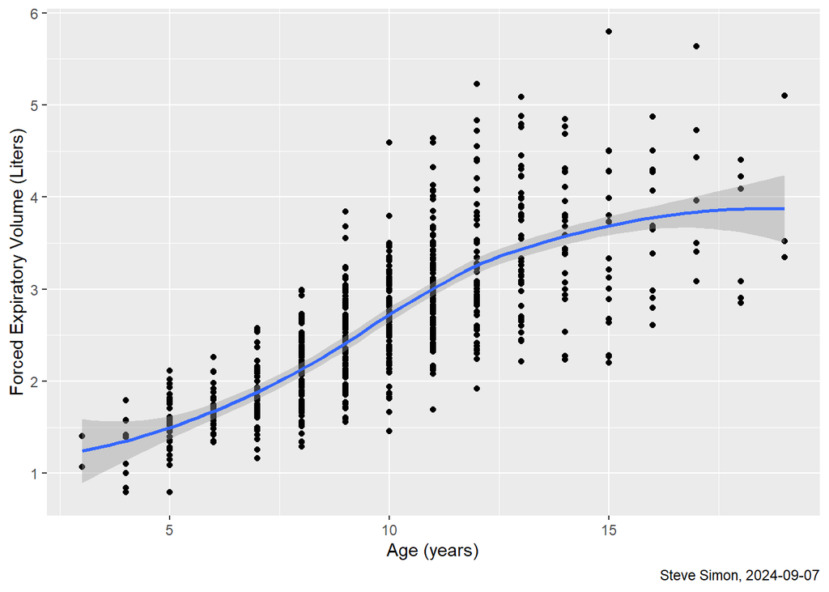

```r
pulmonary |>
  ggplot() +
      aes(age, fev) +
    geom_point() +
    geom_smooth() +
    labs(
      x="Age (years)",
      y="Forced Expiratory Volume (Liters)",
      caption="Steve Simon, 2024-09-07")
```

#### Comments on the code

The [geom_point](https://ggplot2.tidyverse.org/reference/geom_point.html) function adds points on the X and Y axes to create a scatterplot. The [geom_smooth](https://ggplot2.tidyverse.org/reference/geom_smooth.html) function adds a smoothing curve to graph.

#### Interpretation of the output

The is a positive relationship between age and fev, though things seems to level off around 14 years.

## Correlation between age and fev

```r
with(pulmonary, cor(age, fev))
```

```
[1] 0.756459
```

#### Comments on the code

The cor function calculates the correlation between age and fev. The with function identifies pulmonary as the dataset where you can find age and fev.

#### Interpretation of the output

The correlation, 0.75, which supports the plot drawn earlier by showing a strong positive association between age and fev.

## Plot smoke versus fev

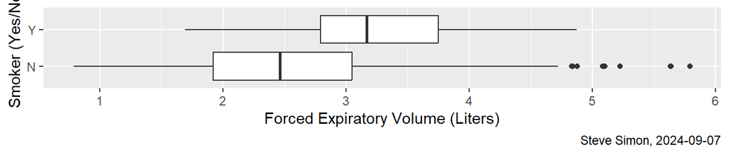

```r
pulmonary |>
  ggplot() +
    aes(fev, smoke) +
    geom_boxplot() +
    labs(
      y="Smoker (Yes/No)",
      x="Forced Expiratory Volume (Liters)",
      caption="Steve Simon, 2024-09-07")
```

#### Comments on the code

The [geom_boxplot function](https://ggplot2.tidyverse.org/reference/geom_boxplot.html) produces a set of boxplots. The categorical variable is clearly smoke, so placing it on the y-axis produces a horizontal set of boxplots.

#### Interpretation of the output

The fev values are larger for smokers versus non-smokers. This is the opposite direction from what we expected.

## Means and standard deviations for smokers and non-smokers.

```r
pulmonary |>
  group_by(smoke) |>
  summarize(
    mean_fev=mean(fev),
    sd_fev=sd(fev))
```

```
# A tibble: 2 × 3
  smoke mean_fev sd_fev
  <chr>    <dbl>  <dbl>
1 N         2.57  0.851
2 Y         3.28  0.750
```

#### Comments on the code

The [group_by function](https://dplyr.tidyverse.org/reference/group_by.html), part of the dplyr and tidyverse libraries, tells R that any further calculations should be done separately for each level of smoke.

## Question 1

Use the simon-5501-04-demo1.qmd file. Update the program to calculate descriptive statistics (mean and standard deviation) for ht. Interpret these statistics.

```r
pulmonary |>
  summarize(
    fev_mean=mean(ht),
    fev_stdv=sd(ht))
```

```
# A tibble: 1 × 2
  fev_mean fev_stdv
     <dbl>    <dbl>
1     61.1     5.70
```

## Question #2

Draw a scatterplot of ht versus fev. Include a smoothing curve. Place ht on the x-axis and fev on the y-axis. Interpret this plot.

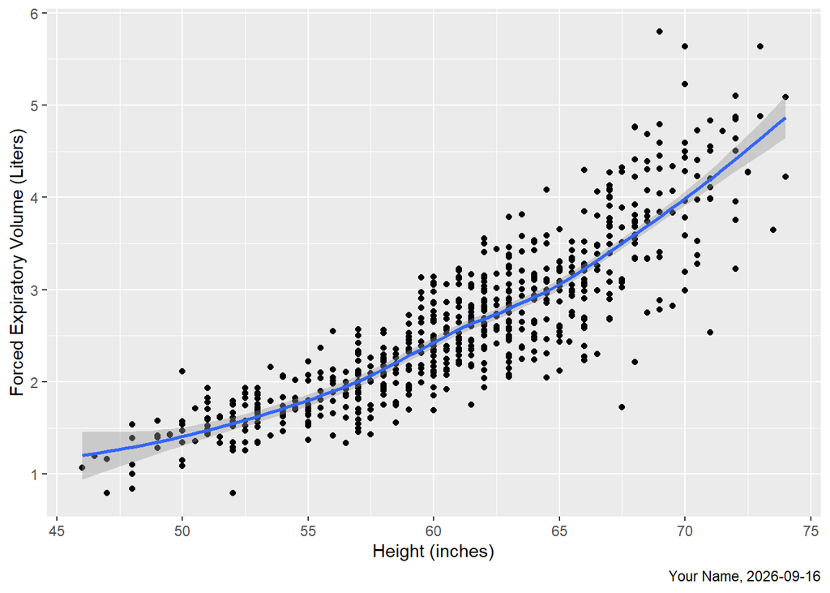

```r
pulmonary |>
  ggplot() +
      aes(ht, fev) +
    geom_point() +
    geom_smooth() +
    labs(
      x="Height (inches)",
      y="Forced Expiratory Volume (Liters)",
      caption="Your Name, 2026-09-16")
```

## Question #3

Calculate the correlation between ht and fev. Interpret this correlation.

```r
with(pulmonary, cor(ht, fev))
```

```
[1] 0.868135
```